# Portland’s Warming Climate

Seasonal distribution of daily high temperatures (1990 - 2026)

Author

Climate Analysis

```r
library(ggplot2)
library(lubridate)
library(readr)

# Load the historical weather dataset
weather_data <- read_csv("portland_daily_highs.csv")

# 1. Data Preparation
# Convert Date to a proper Date object
weather_data$Date <- as.Date(weather_data$Date)

# Create a numeric day_of_year column (1-365) using lubridate::yday()
weather_data$day_of_year <- yday(weather_data$Date)

# 2. Identify the Top 3 Highest Temperature Records
# Sorting descending by Fahrenheit and picking the top 3 rows
top_3_records <- weather_data[order(-weather_data$Max_Temp_F), ][1:3, ]
```

Below is the seasonal distribution of daily high temperatures for Portland, Oregon. Each dot represents a single day’s maximum temperature over the last 36 years, showing the seasonal density (“climate cloud”) alongside the anomalous, all-time record heatwave of June 2021.

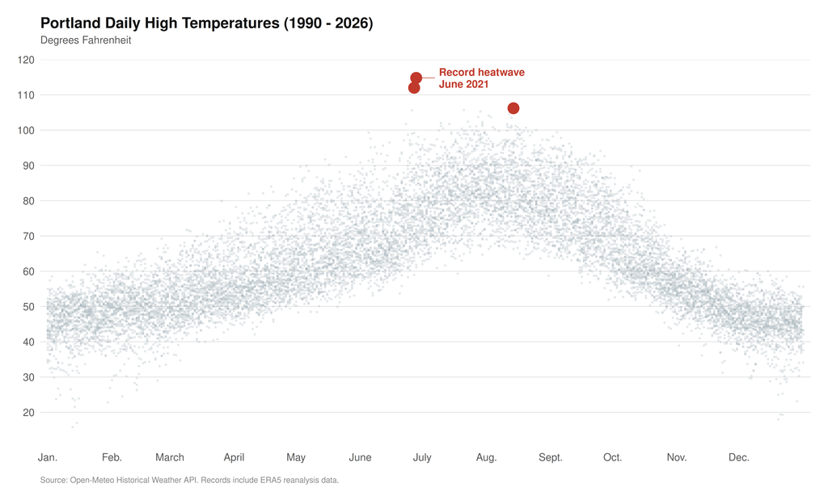

```r
# Define month starts in day-of-year for a standard year (non-leap year)
month_breaks <- c(1, 32, 60, 91, 121, 152, 182, 213, 244, 274, 305, 335)
month_labels <- c("Jan.", "Feb.", "March", "April", "May", "June", "July", "Aug.", "Sept.", "Oct.", "Nov.", "Dec.")

# Create the NYT-style seasonal scatter plot
ggplot(weather_data, aes(x = day_of_year, y = Max_Temp_F)) +
  # Plot all historical highs as a slate-gray "climate cloud"
  geom_point(color = "#a2b1b9", alpha = 0.28, size = 1.0, stroke = 0) +

  # Highlight the top 3 highest temperature records as larger, vivid red dots
  geom_point(data = top_3_records, aes(x = day_of_year, y = Max_Temp_F),
             color = "#c0392b", size = 3.8, stroke = 0.8) +

  # Draw a subtle indicator line connecting the annotation to the heatwave dots
  annotate("segment",
           x = 179 + 2, xend = 179 + 9,
           y = 114.8, yend = 114.8,
           color = "#c0392b",
           linewidth = 0.3,
           alpha = 0.8) +

  # Add the text annotation pointing to the record heatwave
  annotate("text",
           x = 179 + 11,
           y = 114.8,
           label = "Record heatwave\nJune 2021",
           hjust = 0,
           vjust = 0.5,
           color = "#c0392b",
           size = 3.2,
           fontface = "bold",
           lineheight = 0.95) +

  # Adjust axes
  scale_x_continuous(
    breaks = month_breaks,
    labels = month_labels,
    expand = c(0.01, 0.01)
  ) +
  scale_y_continuous(
    breaks = seq(20, 120, by = 10),
    limits = c(10, 120),
    expand = c(0, 0)
  ) +

  # Title, subtitle, and caption styling
  labs(
    title = "Portland Daily High Temperatures (1990 - 2026)",
    subtitle = "Degrees Fahrenheit",
    caption = "Source: Open-Meteo Historical Weather API. Records include ERA5 reanalysis data."
  ) +

  # Minimalist design matching specifications
  theme_minimal() +
  theme(
    # Remove vertical grid lines entirely
    panel.grid.major.x = element_blank(),
    panel.grid.minor.x = element_blank(),

    # Remove minor horizontal lines, keep light major horizontal lines
    panel.grid.minor.y = element_blank(),
    panel.grid.major.y = element_line(color = "#e5e5e5", linewidth = 0.35),

    # Remove axis titles for clean NYT look
    axis.title.x = element_blank(),
    axis.title.y = element_blank(),

    # Text styling
    axis.text = element_text(color = "#555555", size = 9),
    plot.title = element_text(face = "bold", size = 13, color = "#111111", margin = margin(b = 4)),
    plot.subtitle = element_text(size = 9, color = "#555555", margin = margin(b = 12)),
    plot.caption = element_text(size = 7, color = "#888888", hjust = 0, margin = margin(t = 12)),

    # Clean margins
    plot.margin = margin(t = 15, r = 15, b = 10, l = 15)
  )
```

## Key Insights from the Data

### 1. The June 2021 Heatwave as an Extreme Outlier

The red dots representing the June 2021 heatwave (reaching **114.8°F** and **112.0°F**) are completely detached from the rest of the seasonal temperature cloud. This is not just a typical summer peak; it is an extraordinary statistical anomaly sitting nearly 10°F above the next highest historic records for June, demonstrating the severe nature of the Pacific Northwest heat dome event.

### 2. Upward Trend in Temperature Baselines

Analyzing the underlying dataset shows that average highs are shifting upwards. The decade average for the **2020s (62.7°F)** is higher than the **1990s (62.3°F)**, **2000s (62.0°F)**, and **2010s (62.1°F)**. This upward creep is matched by rising maximum records, which have repeatedly breached the 105°F mark in recent years.

### 3. Severe Winter Arctic Outbreaks

The bottom edge of the climate cloud outlines Portland’s winter bounds. While Portland winters are generally mild (daily highs typically in the 40s), periodic Arctic cold fronts drag daytime highs below freezing. The most severe recent outlier is **January 13, 2024 (15.8°F)**, showing that winter extremes can still be severe even amidst general warming trends.